# How well do you work out?

Coursera Week 32: Predicting the motion of the ocean

IC

Decemeber 14, 2017

## Introduction

One thing that people regularly do is quantify how much of a particular activity they do, but they rarely quantify how well they do it. In this project, your goal will be to use data from accelerometers on the belt, forearm, arm, and dumbell of 6 participants. – *From course website*

## Data (files and cleaning)

### Files

The data was supplied by the course convenor and can be found at 1. https://d396qusza40orc.cloudfront.net/predmachlearn/pml-training.csv and 2. https://d396qusza40orc.cloudfront.net/predmachlearn/pml-testing.csv

The data was provieded from http://web.archive.org/web/20161224072740/http:/groupware.les.inf.puc-rio.br/har.

### Cleaning

Columns from the data set which were only or largely containing NA values were removed from the analysis. Also, additional columns were removed which served no use. With the final cleaned data set, the analysis could begin.

The training set was cleaned by:

1. Change all the blank spaces to NA.
2. Eliminated all fields where the count of NA > 0.
3. Eliminate additional fields which are not important.
4. Convert user name and classe fields to factor fields.

Herein lies the code used to clean the training data set:

```r
# Clear Global Environment
rm(list = ls())
options(warn = -1)

# Check for packages, and install if not there
if(!require(rstudioapi)) install.packages("rstudioapi")
if(!require(dplyr)) install.packages("dplyr")
if(!require(zoo)) install.packages("zoo")
if(!require(tidyr)) install.packages("tidyr")
if(!require(bigrquery)) install.packages("bigrquery")
if(!require(lubridate)) install.packages("lubridate")
if(!require(caret)) install.packages("caret")
if(!require(e1071)) install.packages("e1071")
if(!require(pgmm)) install.packages("pgmm")
if(!require(ggplot2)) install.packages("ggplot2")
if(!require(doParallel)) install.packages("doParallel")
if(!require(parallel)) install.packages("parallel")
if(!require(snow)) install.packages("snow")
if(!require(randomForest)) install.packages("randomForest")

# Imports packages
require("rstudioapi")
require("dplyr")
require("zoo")
require("tidyr")
require("bigrquery")
require("lubridate")
require("caret")
require("e1071")
require("pgmm")
require("ggplot2")
require("parallel")
require("doParallel")
require("snow")
require("randomForest")
```

```r
# Working directory
setwd(dirname(rstudioapi::getActiveDocumentContext()$path))

# Load in training set
trData = read.csv("pml-training.csv",stringsAsFactors = F) # training data from site

# replace all "" with NA
trData[trData == ""] = NA

# If there are NAs in the column, record the row number and remove it
x = NA
for(i in 1:ncol(trData))
{
    if(nrow(trData[is.na(trData[,i]),])==0){x = c(x,i)}
}

x = x[!is.na(x)]; trData = trData[,x]

df = trData %>% group_by(user_name,classe) %>% summarise(NUM = length(classe))

# remove fields you don't need at all
toRemove = c("X","raw_timestamp_part_1","raw_timestamp_part_2","cvtd_timestamp","new_window","num_window")
trData = trData[,!(names(trData) %in% toRemove)]

trData$classe = factor(trData$classe)
trData$user_name = factor(trData$user_name)
```

### Model Creation

3 Models were created to model the outcome: Rpart, GBM and RF. These models were developed using a **random sampling** cross validation method. The training data was split into 2 sets - **training set** (75% of the training set data) and a **testing set** (the remaining 25%).

The **training set** was trained on 3 models. All 3 models used a PCA preprocessing to increase the level of correlation between fields, which increases the level of accuracy of the model. For the random forest model (modFitrf), to increase speed, mtry was set to 3. This was a trade off for accuracy of this model.

```r
# split training data into two sets of training and test set
set.seed(47586)

trainValues = createDataPartition(y=trData$classe,p=0.75, list=FALSE)

training = trData[trainValues,]
test = trData[-trainValues,]

# use of Random Forest methods with prox

modFitrpart = train(classe ~.,data = training, method = "rpart",preProcess = "pca")
modFitgbm = train(classe ~.,data = training[,-1], method = "gbm",preProcess = "pca", verbose = F)
modFitrf = train(classe ~.,data = training, method = "rf",preProcess = "pca", tuneGrid = data.frame(mtry = 3))
```

The models were used to predict the test set data. Using the caret package, the function *confusionMatrix* was used to determine the accuracy of each model:

```r
# store confusion matrices
cmRpart = confusionMatrix(test$classe,predict(object = modFitrpart,newdata = test))
cmGBM = confusionMatrix(test$classe,predict(object = modFitgbm,newdata = test))
cmRF = confusionMatrix(test$classe,predict(object = modFitrf,newdata = test))

# accuracy table
acTable = data.frame(Model = c("Rpart", "GBM", "RF"),
                     Accuracy = c(as.numeric(cmRpart$overall[1]), as.numeric(cmGBM$overall[1]), as.numeric(cmRF$overall[1])))
```

```r
acTable
```

```
##   Model  Accuracy
## 1 Rpart 0.3766313
## 2   GBM 0.8358483
## 3    RF 0.9806281
```

We can plot the data of correct(1) vs incorrect(0) predicted counts. A table of the results is attached for clarity of results.

```r
# RF best model, show how good with a graph
rfResults = data.frame(Actual = test$classe, Predicted = predict(object = modFitrf,newdata = test))
rfResults$Same = ifelse(rfResults$Actual == rfResults$Predicted, 1, 0)

rfResults = rfResults %>% group_by(Actual,Same) %>% summarise(Count = length(Actual))
```

```r
as.data.frame(rfResults)
```

```
##    Actual Same Count
## 1       A    0     5
## 2       A    1  1390
## 3       B    0    30
## 4       B    1   919
## 5       C    0    19
## 6       C    1   836
## 7       D    0    27
## 8       D    1   777
## 9       E    0    14
## 10      E    1   887
```

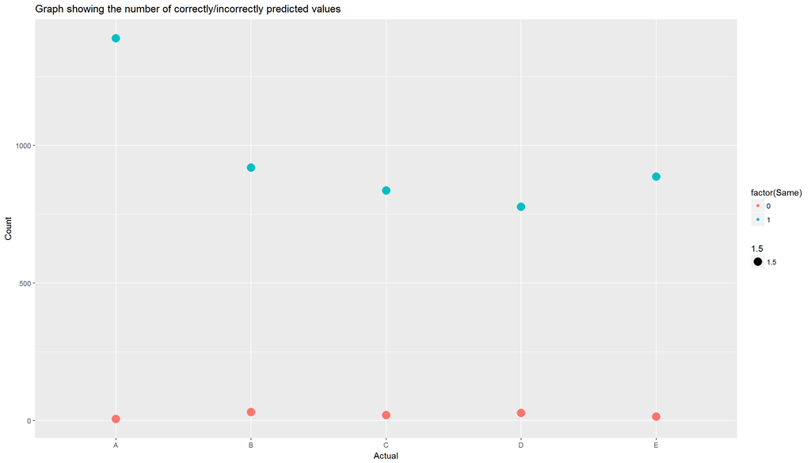

```r
q = qplot(x = Actual, y = Count,data = rfResults, cex = 1.5 ,colour = factor(Same),main = "Graph showing the number of correctly/incorrectly predicted values")
q
```